# Exploración de datos IRIS

2022-09-29

## Importando datos

- Iniciaremos con el conjunto de datos Iris

```r
data("iris") # El conjunto de datos está preinstalado en R
# para aprender a cargar archivos con datos, escribimos:
mydata<-read.table("/home/rosa/Documents/MDD2022/data/iris.data", header = T, sep = ",")
```

- Revisando este comando por argumentos
  - Los datos estan en el archivo llamado `iris.data`. Este archivo se encuentra en el Aula Virtual
  - El archivo si contiene `header` en su primera fila por eso se define como `T` o como `TRUE`
  - El formato csv nos dice que es un archivo con los campos separados por comas `sep=","`
- Podriamos cargar el archivo tambien con el comando **`read.csv()`**, que es similar a `read.table()` pero predeterminado para `sep=","`

Inciamos por explorar la dimensionalidad, nombres de las variables, estructura de los datos y el tipo de datos

```r
dim(mydata)
```

```
## [1] 150   5
```

```r
names(mydata)
```

```
## [1] "Sepalo.Longitud" "Sepalo.Ancho"    "Petalo.Longitud" "Petalo.Ancho"
## [5] "Especie"
```

```r
str(mydata)
```

```
## 'data.frame':    150 obs. of  5 variables:
##  $ Sepalo.Longitud: num  5.1 4.9 4.7 4.6 5 5.4 4.6 5 4.4 4.9 ...
##  $ Sepalo.Ancho   : num  3.5 3 3.2 3.1 3.6 3.9 3.4 3.4 2.9 3.1 ...
##  $ Petalo.Longitud: num  1.4 1.4 1.3 1.5 1.4 1.7 1.4 1.5 1.4 1.5 ...
##  $ Petalo.Ancho   : num  0.2 0.2 0.2 0.2 0.2 0.4 0.3 0.2 0.2 0.1 ...
##  $ Especie        : Factor w/ 3 levels "Iris-setosa",..: 1 1 1 1 1 1 1 1 1 1 ...
```

```r
attributes(mydata)
```

```
## $names
## [1] "Sepalo.Longitud" "Sepalo.Ancho"    "Petalo.Longitud" "Petalo.Ancho"
## [5] "Especie"
##
## $class
## [1] "data.frame"
##
## $row.names
##   [1]   1   2   3   4   5   6   7   8   9  10  11  12  13  14  15  16  17  18
##  [19]  19  20  21  22  23  24  25  26  27  28  29  30  31  32  33  34  35  36
##  [37]  37  38  39  40  41  42  43  44  45  46  47  48  49  50  51  52  53  54
##  [55]  55  56  57  58  59  60  61  62  63  64  65  66  67  68  69  70  71  72
##  [73]  73  74  75  76  77  78  79  80  81  82  83  84  85  86  87  88  89  90
##  [91]  91  92  93  94  95  96  97  98  99 100 101 102 103 104 105 106 107 108
## [109] 109 110 111 112 113 114 115 116 117 118 119 120 121 122 123 124 125 126
## [127] 127 128 129 130 131 132 133 134 135 136 137 138 139 140 141 142 143 144
## [145] 145 146 147 148 149 150
```

Las primera o las últimas filas de datos se pueden recuperar con `head()` o `tail()`, que de forma predeterminada devuelven las primeras o las últimas 6 filas. Alternativamente, podemos obtener un cierto número de filas configurando el segundo parámetro a ambas funciones. Por ejemplo, las primeras 10 filas se obtienen con `head(DATOS,10)`.

```r
head(mydata)
```

```
##   Sepalo.Longitud Sepalo.Ancho Petalo.Longitud Petalo.Ancho     Especie
## 1             5.1          3.5             1.4          0.2 Iris-setosa
## 2             4.9          3.0             1.4          0.2 Iris-setosa
## 3             4.7          3.2             1.3          0.2 Iris-setosa
## 4             4.6          3.1             1.5          0.2 Iris-setosa
## 5             5.0          3.6             1.4          0.2 Iris-setosa
## 6             5.4          3.9             1.7          0.4 Iris-setosa
```

```r
tail(mydata)
```

```
##     Sepalo.Longitud Sepalo.Ancho Petalo.Longitud Petalo.Ancho        Especie
## 145             6.7          3.3             5.7          2.5 Iris-virginica
## 146             6.7          3.0             5.2          2.3 Iris-virginica
## 147             6.3          2.5             5.0          1.9 Iris-virginica
## 148             6.5          3.0             5.2          2.0 Iris-virginica
## 149             6.2          3.4             5.4          2.3 Iris-virginica
## 150             5.9          3.0             5.1          1.8 Iris-virginica
```

```r
head(mydata,10)
```

```
##    Sepalo.Longitud Sepalo.Ancho Petalo.Longitud Petalo.Ancho     Especie
## 1              5.1          3.5             1.4          0.2 Iris-setosa
## 2              4.9          3.0             1.4          0.2 Iris-setosa
## 3              4.7          3.2             1.3          0.2 Iris-setosa
## 4              4.6          3.1             1.5          0.2 Iris-setosa
## 5              5.0          3.6             1.4          0.2 Iris-setosa
## 6              5.4          3.9             1.7          0.4 Iris-setosa
## 7              4.6          3.4             1.4          0.3 Iris-setosa
## 8              5.0          3.4             1.5          0.2 Iris-setosa
## 9              4.4          2.9             1.4          0.2 Iris-setosa
## 10             4.9          3.1             1.5          0.1 Iris-setosa
```

Para obtener los primeras filas de la variable Sepalo.Longitud

```r
mydata[1:10,"Sepalo.Longitud"]
```

```
##  [1] 5.1 4.9 4.7 4.6 5.0 5.4 4.6 5.0 4.4 4.9
```

```r
mydata[,"Sepalo.Longitud"]
```

```
##   [1] 5.1 4.9 4.7 4.6 5.0 5.4 4.6 5.0 4.4 4.9 5.4 4.8 4.8 4.3 5.8 5.7 5.4 5.1
##  [19] 5.7 5.1 5.4 5.1 4.6 5.1 4.8 5.0 5.0 5.2 5.2 4.7 4.8 5.4 5.2 5.5 4.9 5.0
##  [37] 5.5 4.9 4.4 5.1 5.0 4.5 4.4 5.0 5.1 4.8 5.1 4.6 5.3 5.0 7.0 6.4 6.9 5.5
##  [55] 6.5 5.7 6.3 4.9 6.6 5.2 5.0 5.9 6.0 6.1 5.6 6.7 5.6 5.8 6.2 5.6 5.9 6.1
##  [73] 6.3 6.1 6.4 6.6 6.8 6.7 6.0 5.7 5.5 5.5 5.8 6.0 5.4 6.0 6.7 6.3 5.6 5.5
##  [91] 5.5 6.1 5.8 5.0 5.6 5.7 5.7 6.2 5.1 5.7 6.3 5.8 7.1 6.3 6.5 7.6 4.9 7.3
## [109] 6.7 7.2 6.5 6.4 6.8 5.7 5.8 6.4 6.5 7.7 7.7 6.0 6.9 5.6 7.7 6.3 6.7 7.2
## [127] 6.2 6.1 6.4 7.2 7.4 7.9 6.4 6.3 6.1 7.7 6.3 6.4 6.0 6.9 6.7 6.9 5.8 6.8
## [145] 6.7 6.7 6.3 6.5 6.2 5.9
```

```r
mydata[5:15,]
```

```
##    Sepalo.Longitud Sepalo.Ancho Petalo.Longitud Petalo.Ancho     Especie
## 5              5.0          3.6             1.4          0.2 Iris-setosa
## 6              5.4          3.9             1.7          0.4 Iris-setosa
## 7              4.6          3.4             1.4          0.3 Iris-setosa
## 8              5.0          3.4             1.5          0.2 Iris-setosa
## 9              4.4          2.9             1.4          0.2 Iris-setosa
## 10             4.9          3.1             1.5          0.1 Iris-setosa
## 11             5.4          3.7             1.5          0.2 Iris-setosa
## 12             4.8          3.4             1.6          0.2 Iris-setosa
## 13             4.8          3.0             1.4          0.1 Iris-setosa
## 14             4.3          3.0             1.1          0.1 Iris-setosa
## 15             5.8          4.0             1.2          0.2 Iris-setosa
```

## Exploración de los datos

La distribución de las variables se resume con la funcion `summary(DATOS)`

```r
summary(mydata)
```

```
##  Sepalo.Longitud  Sepalo.Ancho   Petalo.Longitud  Petalo.Ancho
##  Min.   :4.300   Min.   :2.000   Min.   :1.000   Min.   :0.100
##  1st Qu.:5.100   1st Qu.:2.800   1st Qu.:1.600   1st Qu.:0.300
##  Median :5.800   Median :3.000   Median :4.350   Median :1.300
##  Mean   :5.843   Mean   :3.054   Mean   :3.759   Mean   :1.199
##  3rd Qu.:6.400   3rd Qu.:3.300   3rd Qu.:5.100   3rd Qu.:1.800
##  Max.   :7.900   Max.   :4.400   Max.   :6.900   Max.   :2.500
##             Especie
##  Iris-setosa    :50
##  Iris-versicolor:50
##  Iris-virginica :50
##
##
##
```

La frequencia de las variables se obtiene con la función `table(DATOS$Variable)`. Se define una variable con el nombre del conjunto datos seguido por el simbolo `$` y el nombre de la variable. Por ejemplo, para definir la variable Especie de nuestros datos escribimos `mydata$Especie`.

```r
table(mydata$Especie)
```

```
##
##     Iris-setosa Iris-versicolor  Iris-virginica
##              50              50              50
```

```r
table(mydata$Petalo.Ancho)
```

```
##
## 0.1 0.2 0.3 0.4 0.5 0.6   1 1.1 1.2 1.3 1.4 1.5 1.6 1.7 1.8 1.9   2 2.1 2.2 2.3
##   6  28   7   7   1   1   7   3   5  13   8  12   4   2  12   5   6   6   3   8
## 2.4 2.5
##   3   3
```

Podemos presentar la misma información con una gráfica de pastel

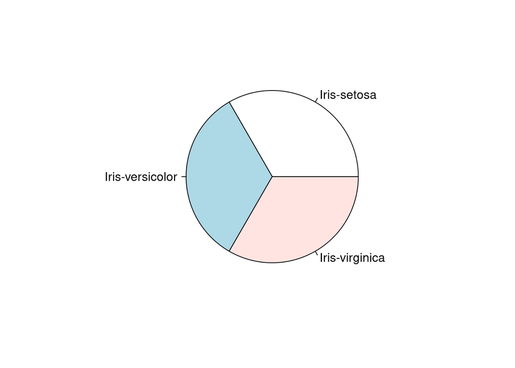

```r
pie(table(mydata$Especie))
```

o un gráfico de barras

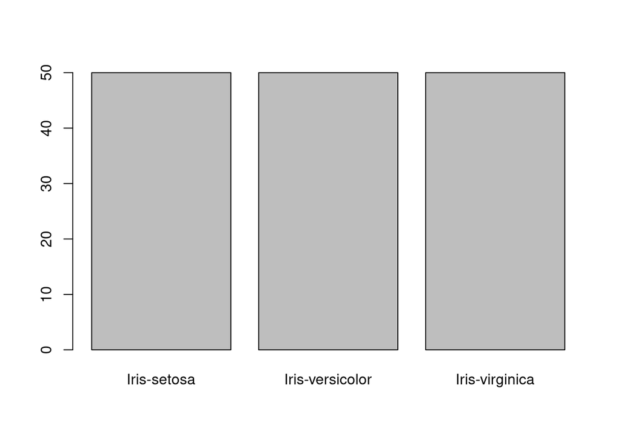

```r
barplot(table(mydata$Especie))
```